# AI and the Labour Market in Croatian Media

Media Framing Analysis (2021–2024)

Author

Luka Sikic

Published

February 9, 2026

# Abstract

This document analyses how Croatian digital media frame the intersection of artificial intelligence and the labour market. The corpus is drawn from the Determ media-monitoring platform (2021–2024) and includes only articles containing both AI-related and labour-market-related keywords (intersection logic). Eight interpretive frames, six actor categories, and automated sentiment are examined across time and media outlet types.

**NoteData preparation**

The corpus was extracted by `R/01_extract_corpus.R` and enriched by `R/02_add_diagnostics.R`. Run those scripts first if the data files are missing.

# 1 Introduction

## 1.1 Background

Technological change has historically reshaped labour demand in ways that were difficult to predict at the time. Artificial intelligence poses a distinctive challenge because it affects not only routine manual tasks but also non-routine cognitive work such as programming, translation, data analysis, and creative writing.

Media do not merely relay facts; they select, omit, and emphasise, thereby actively shaping public perception. The way media frame the impact of AI on work can influence individual behaviour, corporate strategy, and public policy.

## 1.2 Research questions

**RQ1 (Volume and dynamics)** How much media coverage does the AI–labour nexus receive, and how has coverage evolved over time?

**RQ2 (Frames)** Which interpretive frames dominate, and how has their prevalence shifted?

**RQ3 (Actors)** Whose perspectives appear most frequently?

**RQ4 (Sources)** Do different media outlet types frame the topic differently?

# 2 Data

## 2.1 Loading the corpus

```r
if (!file.exists(path_raw_corpus)) {
  stop("Corpus not found at: ", path_raw_corpus,
       "\n\nRun R/01_extract_corpus.R first.")
}

corpus_data <- readRDS(path_raw_corpus)

cat("Corpus loaded successfully\n")
```

```
Corpus loaded successfully
```

```r
cat("Total articles:", format(nrow(corpus_data), big.mark = ","), "\n")
```

```
Total articles: 36,179
```

```r
cat("Date range:", as.character(min(corpus_data$DATE)), "to",
    as.character(max(corpus_data$DATE)), "\n")
```

```
Date range: 2021-01-01 to 2024-07-04
```

```r
cat("Columns:", ncol(corpus_data), "\n")
```

```
Columns: 14
```

```r
corpus_data$.text_lower <- stri_trans_tolower(
  paste(coalesce(corpus_data$TITLE, ""),
        coalesce(corpus_data$FULL_TEXT, ""),
        sep = " ")
)

if (!"year" %in% names(corpus_data)) {
  corpus_data$year <- year(corpus_data$DATE)
}
if (!"year_month" %in% names(corpus_data)) {
  corpus_data$year_month <- floor_date(corpus_data$DATE, "month")
}
if (!"quarter" %in% names(corpus_data)) {
  corpus_data$quarter <- quarter(corpus_data$DATE)
  corpus_data$year_quarter <- paste0(corpus_data$year, " Q", corpus_data$quarter)
}

corpus_data$word_count <- stri_count_regex(corpus_data$FULL_TEXT, "\\S+")

summary_stats <- tibble(
  Metric = c("Total articles", "Unique sources", "Date range",
             "Mean words/article", "Median words/article"),
  Value = c(
    format(nrow(corpus_data), big.mark = ","),
    format(n_distinct(corpus_data$FROM), big.mark = ","),
    paste(min(corpus_data$DATE), "to", max(corpus_data$DATE)),
    round(mean(corpus_data$word_count, na.rm = TRUE)),
    round(median(corpus_data$word_count, na.rm = TRUE))
  )
)

kable(summary_stats, col.names = c("Metric", "Value")) |>
  kable_styling(bootstrap_options = c("striped", "hover"), full_width = FALSE)
```

| Metric | Value |
| --- | --- |
| Total articles | 36,179 |
| Unique sources | 2,150 |
| Date range | 2021-01-01 to 2024-07-04 |
| Mean words/article | 900 |
| Median words/article | 646 |

## 2.2 Source distribution

```r
if ("SOURCE_TYPE" %in% names(corpus_data)) {
  source_dist <- corpus_data |>
    count(SOURCE_TYPE, sort = TRUE) |>
    mutate(pct = round(n / sum(n) * 100, 1))

  kable(source_dist, col.names = c("Source type", "N", "%")) |>
    kable_styling(bootstrap_options = c("striped", "hover"), full_width = FALSE)
}
```

| Source type | N | % |
| --- | --- | --- |
| web | 34244 | 94.7 |
| facebook | 812 | 2.2 |
| youtube | 451 | 1.2 |
| reddit | 303 | 0.8 |
| forum | 283 | 0.8 |
| twitter | 73 | 0.2 |
| comment | 13 | 0.0 |

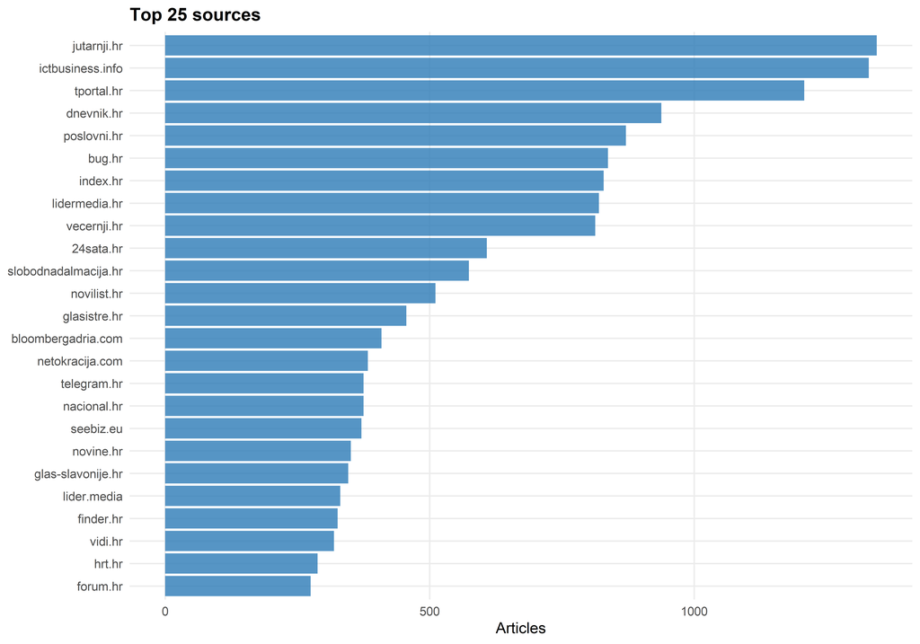

Figure 1: Top 25 sources by article count

```r
top_sources <- corpus_data |>
  count(FROM, sort = TRUE) |>
  head(25)

ggplot(top_sources, aes(x = reorder(FROM, n), y = n)) +
  geom_col(fill = "#2c7bb6", alpha = 0.8) +
  coord_flip() +
  labs(title = "Top 25 sources", x = NULL, y = "Articles")
```

# 3 Temporal dynamics

## 3.1 Monthly volume

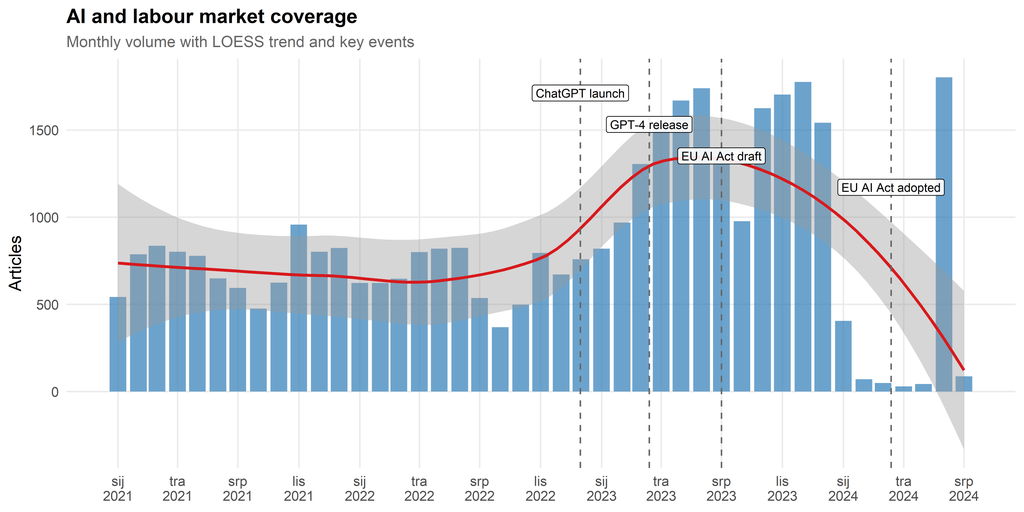

Figure 2: Monthly article volume with key events

```r
monthly_volume <- corpus_data |>
  count(year_month) |>
  filter(!is.na(year_month))

events_cfg <- CONFIG$events
events <- tibble(
  date  = as.Date(sapply(events_cfg, `[[`, "date")),
  label = sapply(events_cfg, `[[`, "label"),
  y_pos = max(monthly_volume$n, na.rm = TRUE) * seq(0.95, by = -0.10,
                                                     length.out = length(events_cfg))
)

ggplot(monthly_volume, aes(x = year_month, y = n)) +
  geom_col(fill = "#2c7bb6", alpha = 0.7) +
  geom_smooth(method = "loess", se = TRUE, color = "#d7191c", linewidth = 1) +
  geom_vline(data = events, aes(xintercept = date),
             linetype = "dashed", color = "gray40") +
  geom_label(data = events, aes(x = date, y = y_pos, label = label),
             size = 3, fill = "white", alpha = 0.9) +
  scale_x_date(date_breaks = "3 months", date_labels = "%b\n%Y") +
  labs(title = "AI and labour market coverage",
       subtitle = "Monthly volume with LOESS trend and key events",
       x = NULL, y = "Articles")
```

## 3.2 Yearly volume

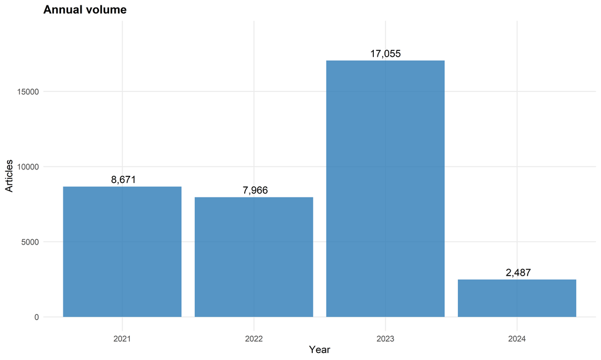

Figure 3: Annual article volume

```r
yearly_volume <- corpus_data |>
  count(year) |>
  filter(!is.na(year))

ggplot(yearly_volume, aes(x = factor(year), y = n)) +
  geom_col(fill = "#2c7bb6", alpha = 0.8) +
  geom_text(aes(label = format(n, big.mark = ",")), vjust = -0.5) +
  labs(title = "Annual volume", x = "Year", y = "Articles") +
  expand_limits(y = max(yearly_volume$n) * 1.1)
```

# 4 Frame analysis

## 4.1 Frame dictionaries

```r
# Build dictionaries from config
frame_dictionaries <- lapply(CONFIG$frames, `[[`, "keywords")

frame_summary <- tibble(
  Frame       = names(frame_dictionaries),
  Description = sapply(CONFIG$frames, `[[`, "description"),
  Keywords    = sapply(frame_dictionaries, length)
)

kable(frame_summary, col.names = c("Frame", "Description", "N keywords")) |>
  kable_styling(bootstrap_options = c("striped", "hover"), full_width = FALSE)
```

| Frame | Description | N keywords |
| --- | --- | --- |
| JOB_LOSS | AI eliminates jobs | 22 |
| JOB_CREATION | AI creates new opportunities | 13 |
| TRANSFORMATION | AI transforms rather than destroys work | 16 |
| SKILLS | Focus on reskilling and education | 14 |
| REGULATION | Policy, governance, and worker protection | 13 |
| PRODUCTIVITY | Economic benefits and efficiency | 11 |
| INEQUALITY | Distributional concerns and digital divide | 11 |
| FEAR_RESISTANCE | Anxiety, fear, and opposition to AI | 16 |

## 4.2 Frame detection

```r
for (frame_name in names(frame_dictionaries)) {
  pattern <- paste(frame_dictionaries[[frame_name]], collapse = "|")
  corpus_data[[paste0("frame_", frame_name)]] <- stri_detect_regex(
    corpus_data$.text_lower, pattern
  )
}

frame_cols <- paste0("frame_", names(frame_dictionaries))
frame_counts <- corpus_data |>
  summarise(across(all_of(frame_cols), sum, na.rm = TRUE)) |>
  pivot_longer(everything(), names_to = "frame", values_to = "count") |>
  mutate(
    frame = str_remove(frame, "frame_"),
    pct   = round(count / nrow(corpus_data) * 100, 1)
  ) |>
  arrange(desc(count))

kable(frame_counts, col.names = c("Frame", "Articles", "% corpus")) |>
  kable_styling(bootstrap_options = c("striped", "hover"), full_width = FALSE)
```

| Frame | Articles | % corpus |
| --- | --- | --- |
| PRODUCTIVITY | 8377 | 23.2 |
| FEAR_RESISTANCE | 6102 | 16.9 |
| SKILLS | 2470 | 6.8 |
| TRANSFORMATION | 1908 | 5.3 |
| JOB_CREATION | 1669 | 4.6 |
| REGULATION | 1613 | 4.5 |
| INEQUALITY | 707 | 2.0 |
| JOB_LOSS | 673 | 1.9 |

[figure not shown]

Figure 4: Frame prevalence

```r
ggplot(frame_counts, aes(x = reorder(frame, count), y = count, fill = frame)) +
  geom_col(alpha = 0.8) +
  geom_text(aes(label = paste0(pct, "%")), hjust = -0.1, size = 3.5) +
  coord_flip() +
  scale_fill_manual(values = frame_colors, guide = "none") +
  labs(title = "Interpretive frame prevalence",
       subtitle = "Percentage of articles containing frame keywords",
       x = NULL, y = "Articles") +
  expand_limits(x = max(frame_counts$count) * 1.15)
```

## 4.3 Frame evolution

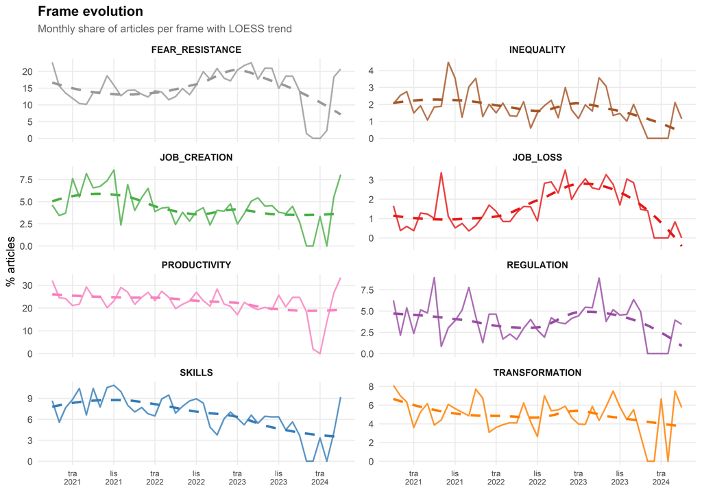

Figure 5: Frame evolution over time

```r
frame_monthly <- corpus_data |>
  group_by(year_month) |>
  summarise(
    n_total = n(),
    across(all_of(frame_cols), sum, na.rm = TRUE)
  ) |>
  pivot_longer(cols = all_of(frame_cols),
               names_to = "frame", values_to = "count") |>
  mutate(
    frame = str_remove(frame, "frame_"),
    pct   = count / n_total * 100
  ) |>
  filter(!is.na(year_month))

ggplot(frame_monthly, aes(x = year_month, y = pct, color = frame)) +
  geom_line(linewidth = 0.8, alpha = 0.8) +
  geom_smooth(method = "loess", se = FALSE, linewidth = 1.2, linetype = "dashed") +
  facet_wrap(~frame, ncol = 2, scales = "free_y") +
  scale_color_manual(values = frame_colors, guide = "none") +
  scale_x_date(date_breaks = "6 months", date_labels = "%b\n%Y") +
  labs(title = "Frame evolution",
       subtitle = "Monthly share of articles per frame with LOESS trend",
       x = NULL, y = "% articles") +
  theme(axis.text.x = element_text(size = 8))
```

# 5 Actor analysis

```r
actor_dictionaries <- CONFIG$actors

for (actor_name in names(actor_dictionaries)) {
  pattern <- paste(actor_dictionaries[[actor_name]], collapse = "|")
  corpus_data[[paste0("actor_", actor_name)]] <- stri_detect_regex(
    corpus_data$.text_lower, pattern
  )
}

actor_cols <- paste0("actor_", names(actor_dictionaries))
actor_counts <- corpus_data |>
  summarise(across(all_of(actor_cols), sum, na.rm = TRUE)) |>
  pivot_longer(everything(), names_to = "actor", values_to = "count") |>
  mutate(
    actor = str_remove(actor, "actor_"),
    pct   = round(count / nrow(corpus_data) * 100, 1)
  ) |>
  arrange(desc(count))

kable(actor_counts, col.names = c("Actor", "Articles", "% corpus")) |>
  kable_styling(bootstrap_options = c("striped", "hover"), full_width = FALSE)
```

| Actor | Articles | % corpus |
| --- | --- | --- |
| EMPLOYERS | 18712 | 51.7 |
| TECH_COMPANIES | 15757 | 43.6 |
| EXPERTS | 13797 | 38.1 |
| WORKERS | 12516 | 34.6 |
| POLICY_MAKERS | 10164 | 28.1 |
| UNIONS | 734 | 2.0 |

[figure not shown]

Figure 6: Actor prevalence

```r
ggplot(actor_counts, aes(x = reorder(actor, count), y = count)) +
  geom_col(fill = "#377eb8", alpha = 0.8) +
  geom_text(aes(label = paste0(pct, "%")), hjust = -0.1, size = 3.5) +
  coord_flip() +
  labs(title = "Actor prevalence", x = NULL, y = "Articles") +
  expand_limits(x = max(actor_counts$count) * 1.15)
```

# 6 Outlet classification

```r
outlet_cfg <- CONFIG$outlet_types

corpus_data$outlet_type <- "Other"
for (type_name in names(outlet_cfg)) {
  for (pat in outlet_cfg[[type_name]]) {
    matches <- stri_detect_regex(stri_trans_tolower(corpus_data$FROM), pat)
    corpus_data$outlet_type[matches] <- type_name
  }
}

outlet_dist <- corpus_data |>
  count(outlet_type, sort = TRUE) |>
  mutate(pct = round(n / sum(n) * 100, 1))

kable(outlet_dist, col.names = c("Outlet type", "N", "%")) |>
  kable_styling(bootstrap_options = c("striped", "hover"), full_width = FALSE)
```

| Outlet type | N | % |
| --- | --- | --- |
| Other | 24228 | 67.0 |
| Quality | 5007 | 13.8 |
| Business | 2598 | 7.2 |
| Tabloid | 1644 | 4.5 |
| Tech | 1282 | 3.5 |
| Regional | 1085 | 3.0 |
| Public | 335 | 0.9 |

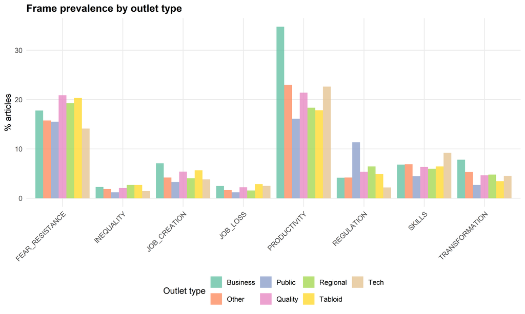

Figure 7: Frame prevalence by outlet type

```r
min_articles <- CONFIG$analysis$min_articles_per_outlet

frames_by_outlet <- corpus_data |>
  group_by(outlet_type) |>
  summarise(
    n = n(),
    across(all_of(frame_cols), ~sum(.x, na.rm = TRUE) / n() * 100)
  ) |>
  filter(n >= min_articles) |>
  pivot_longer(cols = all_of(frame_cols),
               names_to = "frame", values_to = "pct") |>
  mutate(frame = str_remove(frame, "frame_"))

ggplot(frames_by_outlet, aes(x = frame, y = pct, fill = outlet_type)) +
  geom_col(position = "dodge", alpha = 0.8) +
  scale_fill_brewer(palette = "Set2") +
  labs(title = "Frame prevalence by outlet type",
       x = NULL, y = "% articles", fill = "Outlet type") +
  theme(axis.text.x = element_text(angle = 45, hjust = 1))
```

# 7 Sentiment analysis

```r
if ("AUTO_SENTIMENT" %in% names(corpus_data)) {
  sentiment_dist <- corpus_data |>
    count(AUTO_SENTIMENT, sort = TRUE) |>
    mutate(pct = round(n / sum(n) * 100, 1))

  kable(sentiment_dist, col.names = c("Sentiment", "N", "%")) |>
    kable_styling(bootstrap_options = c("striped", "hover"), full_width = FALSE)
} else {
  cat("AUTO_SENTIMENT column not available in corpus.\n")
}
```

| Sentiment | N | % |
| --- | --- | --- |
| positive | 24431 | 67.5 |
| negative | 6330 | 17.5 |
| neutral | 5418 | 15.0 |

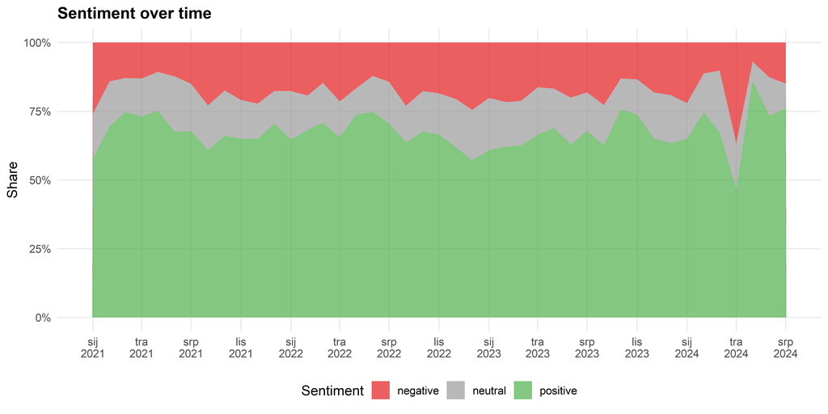

Figure 8: Sentiment distribution over time

```r
if ("AUTO_SENTIMENT" %in% names(corpus_data)) {
  sentiment_monthly <- corpus_data |>
    filter(!is.na(AUTO_SENTIMENT) & !is.na(year_month)) |>
    count(year_month, AUTO_SENTIMENT) |>
    group_by(year_month) |>
    mutate(pct = n / sum(n)) |>
    ungroup()

  ggplot(sentiment_monthly, aes(x = year_month, y = pct, fill = AUTO_SENTIMENT)) +
    geom_area(alpha = 0.7) +
    scale_fill_manual(values = c(
      "positive" = "#4daf4a", "Positive" = "#4daf4a",
      "neutral"  = "gray60",  "Neutral"  = "gray60",
      "negative" = "#e41a1c", "Negative" = "#e41a1c"
    )) +
    scale_y_continuous(labels = scales::percent) +
    scale_x_date(date_breaks = "3 months", date_labels = "%b\n%Y") +
    labs(title = "Sentiment over time",
         x = NULL, y = "Share", fill = "Sentiment")
}
```

# 8 Sample articles

```r
set.seed(CONFIG$analysis$seed)
sample_articles <- corpus_data |>
  slice_sample(n = min(30, nrow(corpus_data))) |>
  select(DATE, TITLE, FROM) |>
  arrange(DATE)

kable(sample_articles, col.names = c("Date", "Title", "Source")) |>
  kable_styling(bootstrap_options = c("striped", "hover", "condensed"),
                full_width = FALSE, font_size = 11) |>
  scroll_box(height = "400px")
```

| Date | Title | Source |
| --- | --- | --- |
| 2021-01-03 | Produktivnost bez BS-a | split-techcity.com |
| 2021-01-07 | Serengeti želi rast u zapadnoj Europi, a 2020. završavaju na sličnim razinama prihoda i dobiti kao 2019. | ictbusiness.info |
| 2021-01-10 | Stručnjaci predviđaju da bi u idućih 20 godina ovih 12 poslova moglo nestati. Je li i vaš među njima? | sbonline.net |
| 2021-09-23 | Huawei predstavio nadolazeće trendove u idućem desetljeću | seebiz.eu |
| 2021-11-24 | Novi poslovi u Osijeku i okolici: Traže Vas Thermia kamini, Ancona grupa, Mehanotehna... | osijekexpress.com |
| 2022-01-11 | 'Sve na 15 minuta', inteligentna mobilnost... Što Zagreb može prigrliti već za 8 godina? - Poslovni dnevnik | poslovni.hr |
| 2022-01-24 | Tko je nasljednica Dubravke Vrgoč? Opernu primadonu već slave u HNK, a u velikom intervju otkrila je ambiciozne planove | zagreb.info |
| 2022-01-27 | AC Group: Vlastito iskustvo i znanje pretočili u razvoj uspješne obiteljske firme | varazdinske-vijesti.hr |
| 2022-03-21 | poslovniFM | poslovnifm.com |
| 2022-04-27 | Samsung Galaxy S22 serija pametnih telefona i dobar AI su dokaz besprijekorne kvalitete | hcl.hr |
| 2022-06-09 | RITTAL i KONČAR - Digital partneri u izgradnji podatkovnih centara i digitalizaciji regije - Poslovni dnevnik | poslovni.hr |
| 2022-08-08 | Kurkumin - polifenol koji ne prestaje biti zagonetka | inpharma.hr |
| 2022-09-16 | Matej Dujmović: Tvrtke moraju početi razmišljati o automatizaciji skladišnih i proizvodnih procesa | lidermedia.hr |
| 2022-11-24 | Preko 70 stručnih predavača 1.12. u Zagrebu na konferenciji koja mijenja sve! | 24sata.hr |
| 2023-01-06 | Terra Meera - čudesno mjesto mira i regeneracije u dalmatinskom zaleđu | grazia.hr |
| 2023-04-06 | Bowery Farming - integrirane farme | gospodarski.hr |
| 2023-05-27 | Sektori industrije i infrastrukture s najboljim izgledima | seebiz.eu |
| 2023-06-08 | Snowden ponovno upozorava svijet! Njegovo otkriće je 'dječja igra' u odnosu na to što danas rade ljudima: Nadzor otišao predaleko | dnevno.hr |
| 2023-06-30 | sudjelovalo na predstavljanju Europskog digitalnog centra inovacija CROBOHUB++ - Sveučilišni računski centar (Srce) | unizg.hr |
| 2023-07-17 | Vijeće sigurnosti UN-a održat će prvu sjednicu o umjetnoj inteligenciji | novilist.hr |
| 2023-07-26 | Tomislav Miletić - Trgovci Novim I Rabljim Automobilima Doživjet Će Darqinovu Evoluciju | lidermedia.hr |
| 2023-08-30 | PC Chip | pcchip.hr |
| 2023-09-28 | OpenAI bi mogao vrijediti gotovo 100 milijardi dolara | tportal.hr |
| 2023-10-20 | M. Kepec: Kako postati uspješan DevOps inženjer | glas-slavonije.hr |
| 2023-11-20 | Prošli tjedan smo kroz naš PPK (PAR Poduzetnički Kamp) uronili u svijet poduzetništva! 🚀 Započeli smo s predavanjem o temi, formirali timove i započeli... \| | eleučilište PAR \| |
| 2024-01-01 | Po čemu ćemo pamtiti 2023.? - Od rata Izraela i Hamasa do utrke na Mjesec | leportale.com |
| 2024-01-01 | Umjetna inteligencija donosi LIČKI HOROSKOP za 2024.: "Financijski uspjeh vam je nadohvat šape!" | likaclub.eu |
| 2024-01-02 | Milanovićev ekonomist naveo pet ključnih ekonomskih izazova za koje sumnja da će ih rješavati Plenković | hrvatska-danas.com |
| 2024-01-08 | Svjetske burze u 2024. godini: Kakvi su trendovi? | n1info.hr |
| 2024-06-14 | Administrativni referent (m/ž) - Dugopolje - S+B Systemtechnik d.o.o. | mojposao.hr |

# 9 Summary

```r
n_articles    <- nrow(corpus_data)
date_range    <- paste(min(corpus_data$DATE), "to", max(corpus_data$DATE))
n_sources     <- n_distinct(corpus_data$FROM)
top_frame     <- frame_counts$frame[1]
top_frame_pct <- frame_counts$pct[1]

cat("ANALYSIS SUMMARY\n")
```

```
ANALYSIS SUMMARY
```

```r
cat("================\n\n")
cat("Total articles:", format(n_articles, big.mark = ","), "\n")
```

```
Total articles: 36,179
```

```r
cat("Period:", date_range, "\n")
```

```
Period: 2021-01-01 to 2024-07-04
```

```r
cat("Sources:", format(n_sources, big.mark = ","), "\n")
```

```
Sources: 2,150
```

```r
cat("Dominant frame:", top_frame, "(", top_frame_pct, "% of articles)\n")
```

```
Dominant frame: PRODUCTIVITY ( 23.2 % of articles)
```

# 10 Data export

```r
export_data <- corpus_data |> select(-`.text_lower`)
saveRDS(export_data, path_analysed_corpus)
```